# Python clustering on text

# Introduction

Author: Chao Lu, cl1486

Dataset: cleaned_twitter_withLabel.csv

Label: tweet topic

Features: Bow and TfIdf dataframe

# Packages

```python
import pandas as pd
import numpy as np
from wordcloud import WordCloud
import matplotlib.pyplot as plt
import seaborn as sns
import re

from sklearn.feature_extraction.text import CountVectorizer
from sklearn.feature_extraction.text import TfidfVectorizer
from sklearn.cluster import KMeans
from sklearn.decomposition import PCA
from sklearn.cluster import AgglomerativeClustering
from sklearn import preprocessing
from sklearn.preprocessing import StandardScaler

from scipy.cluster.hierarchy import dendrogram

from nltk.stem import PorterStemmer
```

```python
import warnings
warnings.filterwarnings("ignore")
```

```python
data = pd.read_csv('cleaned_twitter_withLabel.csv',encoding='utf8',index_col=0) # ,nrows=99
```

```python
data.head()
```

|  | topic | text |
| --- | --- | --- |
| 0 | nft | fishytankgame best project congratulation team... |
| 1 | nft | fishytankgame game busy greet project playtoea... |
| 2 | nft | fishytankgame great excellent project thanhlua... |
| 3 | nft | fishytankgame token boom recommend crypto frie... |
| 4 | bitcoin | lorren find bitcoin green vault location join ... |

# EDA and data cleaning

## Labels

There are four labels represent four twitter topics: NFT tweet, Capflow tweet, Bitcoin tweet and Eth tweet

```python
data['topic'].value_counts()
```

```
nft         2170
Capflow     1419
bitcoin      708
ethereum     696
Name: topic, dtype: int64
```

```python
data_nft = data[data['topic'] == 'nft']
data_Capflow = data[data['topic'] == 'Capflow']
data_bitcoin = data[data['topic'] == 'bitcoin']
data_ethereum = data[data['topic'] == 'ethereum']
```

```python
text_nft = (' ').join(data_nft['text'])
text_Capflow = (' ').join(data_Capflow['text'])
text_bitcoin = (' ').join(data_bitcoin['text'])
text_ethereum = (' ').join(data_ethereum['text'])
```

## Stop words filtering

There are several meaningless words in the whole dataset, like "numbr","https","co" and "cryptocurrency".

```python
stop_words = ['numbr','https','co','cryptocurrency','hrs']
```

## Wordcloud EDA

### NFT topic keywords

There are several interesting things from observing the wordcloud:

NFT topic: playtoearn, airdrop, pancakeswap, binance, bscmateverse.

NFT market now is in an expanding trend and there are a lot of "airdrop" activities on NFT. For example, a few days ago, the "metaverse" platform declare an "airdrop" session, and this may be the reason that why there is a keyword of "metaverse".

Beyond that, one of the famous exchange platform "Binance" also plan to do a similar "airdrop" session on its "BSC" chain.

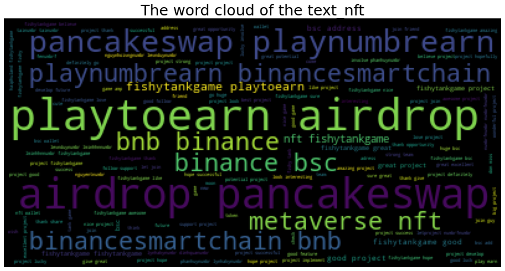

```python
wordcloud = WordCloud(min_word_length = 2,max_words = 200,stopwords=stop_words).generate(text_nft)
fig = plt.figure(figsize=(15,10))
plt.imshow(wordcloud)
plt.axis("off")
plt.title('The word cloud of the text_nft',fontsize = 25)
# fig.savefig('text_nft.png')
```

### Capflow topic keywords

There are several keywords like Spot, Trading, Change, Price, and so on.

Keywords related to the capflow are most about the market quotes. For example, most people will pay more attention to what will the price of a certain token change or will there be crash currently, and other similar kinds of this questions

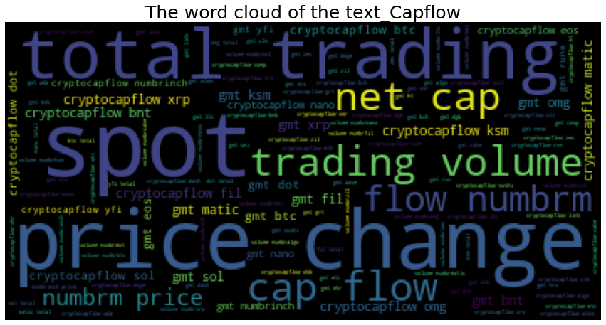

```python
wordcloud = WordCloud(min_word_length = 2,max_words = 200,stopwords=stop_words).generate(text_Capflow)
fig = plt.figure(figsize=(15,10))
plt.imshow(wordcloud)
plt.axis("off")
plt.title('The word cloud of the text_Capflow',fontsize = 25)
# fig.savefig('text_Capflow.png')
```

### Bitcoin topic keywords

Keywords: join, play, coinhuntworld, find, bitcoin, vault.

The bitcoin-related tweets are mostly talking about things from a macro level. For example, the keyword "Coinhuntworld" represents a good trend and atmosphere of people who believe in the cryptocurrency, hoping that crypto technology will change the world.

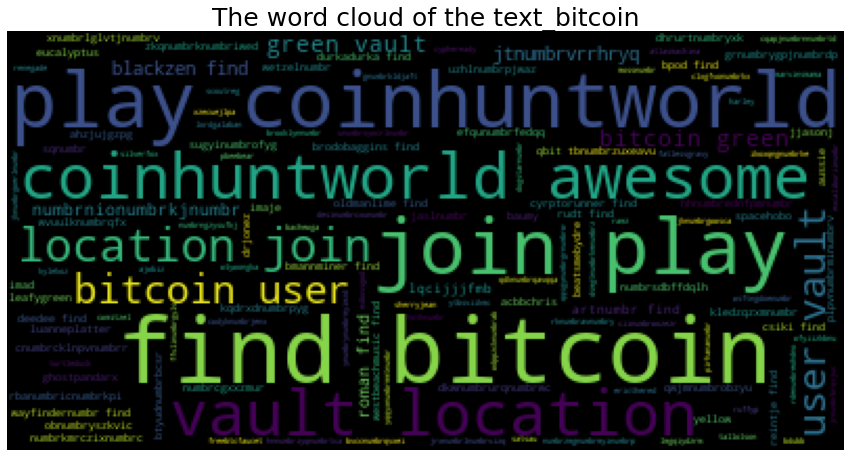

```python
wordcloud = WordCloud(min_word_length = 2,max_words = 200,stopwords=stop_words).generate(text_bitcoin)
fig = plt.figure(figsize=(15,10))
plt.imshow(wordcloud)
plt.axis("off")
plt.title('The word cloud of the text_bitcoin',fontsize = 25)
# fig.savefig('text_bitcoin.png')
```

### Ethereum topic keywords

Keywords: join, play,coinhuntworld, awesome.

The ETH-related topics have a close discussion atmosphere with the Bitcoin-related topic. Both are in a positive topic square.

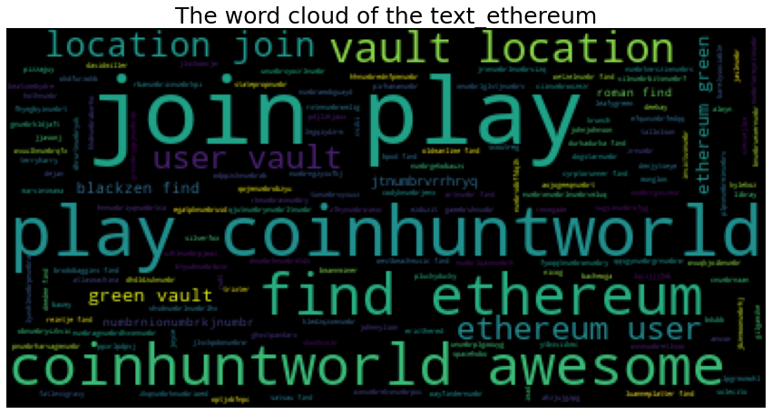

```python
wordcloud = WordCloud(min_word_length = 2,max_words = 200,stopwords=stop_words).generate(text_ethereum)
fig = plt.figure(figsize=(15,10))
plt.imshow(wordcloud)
plt.axis("off")
plt.title('The word cloud of the text_ethereum',fontsize = 25)
# fig.savefig('text_ethereum.png')
```

## data Vectorization

#### Divide the data and label.

```python
text = data['text']
label = data['topic']
```

#### Define the stop words

```python
A_STEMMER=PorterStemmer()
#----------------------------------------
# Use NLTK's PorterStemmer in a function - DEFINE THE FUNCTION
#-------------------------------------------------------
def MY_STEMMER(str_input):
    ## Only use letters, no punct, no nums, make lowercase...
    words = re.sub(r"[^A-Za-z\-]", " ", str_input).lower().split()
    words = [A_STEMMER.stem(word) for word in words] ## Use the Stemmer...
    return words
```

#### Vectorization of data

```python
## Tf-idf vectorizer
MyTfidf=TfidfVectorizer(input='content',
                        stop_words='english',
                        # max_features=200,
                        tokenizer=MY_STEMMER,
                        lowercase=True
                        )

## Create a CountVectorizer object that you can use with the Stemmer
MyBOW = CountVectorizer(input="content",
                        stop_words='english',
                        # max_features=200,
                        tokenizer=MY_STEMMER,
                        lowercase=True)
```

```python
Tfidf_data=MyTfidf.fit_transform(text)
BOW_data=MyBOW.fit_transform(text)
```

```python
DF_tfidf=pd.DataFrame(Tfidf_data.toarray(),columns=MyTfidf.get_feature_names())
DF_BOW=pd.DataFrame(BOW_data.toarray(),columns=MyBOW.get_feature_names())
```

```python
DF_tfidf=DF_tfidf.rename(label, axis="index")
DF_BOW=DF_BOW.rename(label, axis="index")
```

```python
DF_BOW.head()
```

|  | aa | aaaasui | aaainsley | aakso | aanagst | aanumbrnvkpexo | aanumbruorgfiu | aarishnumbr | aaronhanumbr | aaronsmnumbr | ... | zyinumbrfmkdmd | zymurg | zynumbrmzxznumbrb | zyqnumbr | zysxwutlw | zz | zzjohzz | zzlpmapxsnumbr | zznumbruampcso | zzoortinumbra |
| --- | --- | --- | --- | --- | --- | --- | --- | --- | --- | --- | --- | --- | --- | --- | --- | --- | --- | --- | --- | --- | --- |
| nft | 0 | 0 | 0 | 0 | 0 | 0 | 0 | 0 | 0 | 0 | ... | 0 | 0 | 0 | 0 | 0 | 0 | 0 | 0 | 0 | 0 |
| nft | 0 | 0 | 0 | 0 | 0 | 0 | 0 | 0 | 0 | 0 | ... | 0 | 0 | 0 | 0 | 0 | 0 | 0 | 0 | 0 | 0 |
| nft | 0 | 0 | 0 | 0 | 0 | 0 | 0 | 0 | 0 | 0 | ... | 0 | 0 | 0 | 0 | 0 | 0 | 0 | 0 | 0 | 0 |
| nft | 0 | 0 | 0 | 0 | 0 | 0 | 0 | 0 | 0 | 0 | ... | 0 | 0 | 0 | 0 | 0 | 0 | 0 | 0 | 0 | 0 |
| bitcoin | 0 | 0 | 0 | 0 | 0 | 0 | 0 | 0 | 0 | 0 | ... | 0 | 0 | 0 | 0 | 0 | 0 | 0 | 0 | 0 | 0 |

5 rows × 10541 columns

# K-means clustering

The following plot tried different methods of clustering on BOW and TfIdf dataset seperately

```python
def k_means_plot(k,data,plot_name):
    kmeans_object= KMeans(n_clusters=k)
    kmeans_object.fit(data)
    labels = kmeans_object.labels_
    prediction_kmeans = kmeans_object.predict(data)

    pca_count = PCA(n_components=2,random_state = 1004)
    reduce_data = pca_count.fit_transform(data)
    reduce_center = pca_count.transform(kmeans_object.cluster_centers_)


    X = StandardScaler().fit_transform(reduce_data)
    le = preprocessing.LabelEncoder()
    labels_true =  le.fit_transform(label)


    print("Completeness: %0.3f" % metrics.completeness_score(labels_true, labels))
    print("V-measure: %0.3f" % metrics.v_measure_score(labels_true, labels))
    print("Adjusted Rand Index: %0.3f"
        % metrics.adjusted_rand_score(labels_true, labels))
    print("Adjusted Mutual Information: %0.3f"
        % metrics.adjusted_mutual_info_score(labels_true, labels))
    print("Silhouette Coefficient: %0.3f"
        % metrics.silhouette_score(X, labels))

    # plot
    ax = plt.figure(figsize=(10,7))
    sns.scatterplot(x=reduce_data[:,0], y=reduce_data[:,1], hue=prediction_kmeans)
    plt.title(f'{plot_name} clustering (k = {k}) ')
    plt.ylabel('PCA 2')
    plt.xlabel('PCA 1')
    # ax.savefig(f'{plot_name}_{k}.png')
```

## Clustering on BOW (k=3)

In this plot, it seems that there is an outlier in the right up corner of the dataset.

Overall, the clustering on BOW (k=3) performs a pretty good distinction between different data points

```
Completeness: 0.998
V-measure: 0.916
Adjusted Rand Index: 0.910
Adjusted Mutual Information: 0.916
Silhouette Coefficient: 0.953
```

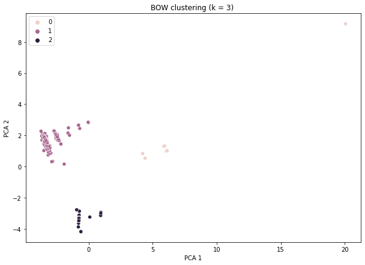

```python
k_means_plot(3,DF_BOW,'BOW')
```

## Clustering on BOW (k=4)

```
Completeness: 0.847
V-measure: 0.847
Adjusted Rand Index: 0.816
Adjusted Mutual Information: 0.846
Silhouette Coefficient: 0.723
```

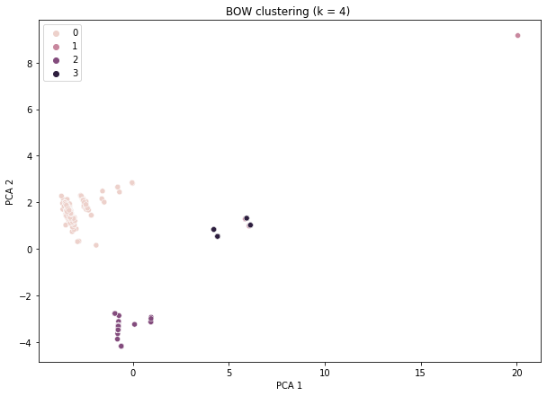

```python
k_means_plot(4,DF_BOW,'BOW')
```

## Clustering on BOW (k=5)

Similiar result with the clustering, there are not much effect on the main data point clust

```
Completeness: 0.781
V-measure: 0.812
Adjusted Rand Index: 0.784
Adjusted Mutual Information: 0.812
Silhouette Coefficient: 0.893
```

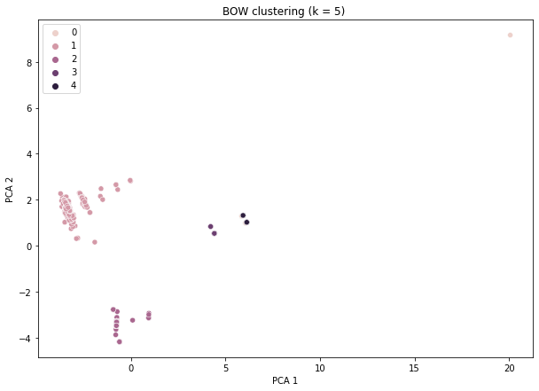

```python
k_means_plot(5,DF_BOW,'BOW')
```

## Clustering on tfidf (k=3)

Compared with the BOW dataset, the k-means clustering result on the TfIdf shows a much more clear boundary between different data clustering. It seems that the optimal option of k should be 3.

However, this optimal k value is not the same as the label. Perhaps more research should be done to find the reason.

```
Completeness: 1.000
V-measure: 0.917
Adjusted Rand Index: 0.911
Adjusted Mutual Information: 0.917
Silhouette Coefficient: 0.923
```

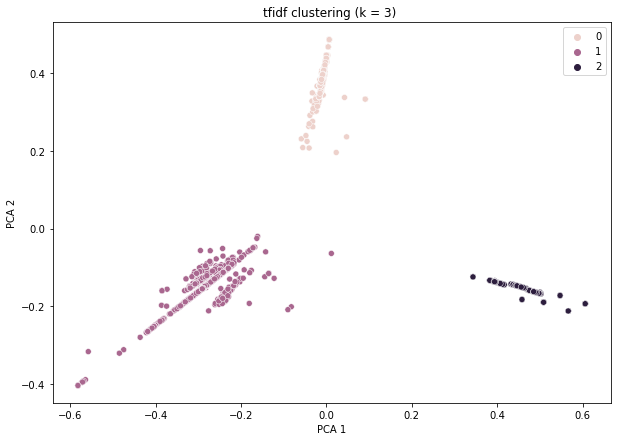

```python
k_means_plot(3,DF_tfidf,'tfidf')
```

## Clustering on tfidf (k=4)

```
Completeness: 0.849
V-measure: 0.848
Adjusted Rand Index: 0.816
Adjusted Mutual Information: 0.848
Silhouette Coefficient: 0.724
```

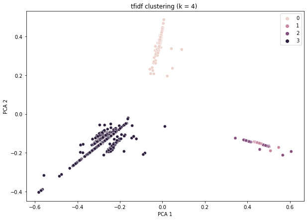

```python
k_means_plot(4,DF_tfidf,'tfidf')
```

## Clustering on tfidf (k=5)

```
Completeness: 0.783
V-measure: 0.813
Adjusted Rand Index: 0.784
Adjusted Mutual Information: 0.813
Silhouette Coefficient: 0.827
```

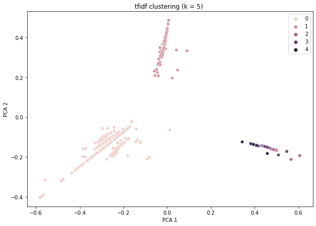

```python
k_means_plot(5,DF_tfidf,'tfidf')
```

## Final choice on the k values

K = 3

```
Completeness: 0.998
V-measure: 0.916
Adjusted Rand Index: 0.910
Adjusted Mutual Information: 0.916
Silhouette Coefficient: 0.953

Completeness: 1.000
V-measure: 0.917
Adjusted Rand Index: 0.911
Adjusted Mutual Information: 0.917
Silhouette Coefficient: 0.923
```

K = 4

```
Completeness: 0.847
V-measure: 0.847
Adjusted Rand Index: 0.816
Adjusted Mutual Information: 0.846
Silhouette Coefficient: 0.723

Completeness: 0.849
V-measure: 0.848
Adjusted Rand Index: 0.816
Adjusted Mutual Information: 0.848
Silhouette Coefficient: 0.724
```

K = 5

```
Completeness: 0.781
V-measure: 0.812
Adjusted Rand Index: 0.784
Adjusted Mutual Information: 0.812
Silhouette Coefficient: 0.893

Completeness: 0.783
V-measure: 0.813
Adjusted Rand Index: 0.784
Adjusted Mutual Information: 0.813
Silhouette Coefficient: 0.827
```

With the aboving indicator on choosing the k value, when k = 3, all the indicators implied that k should be 3.

# Choosing K value of k-means clustering

## Elbow method of clustering (Tf-Idf)

It seems that k should be 3 under the elbow method.

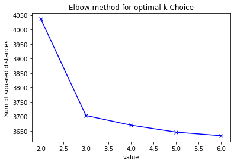

```python
# elbow method of DF_tfidf
SS_dist = []

values_for_k=range(2,7)
#print(values_for_k)

for k_val in values_for_k:

    k_means = KMeans(n_clusters=k_val)
    model = k_means.fit(DF_tfidf)
    SS_dist.append(k_means.inertia_)

plt.plot(values_for_k, SS_dist, 'bx-')
plt.xlabel('value')
plt.ylabel('Sum of squared distances')
plt.title('Elbow method for optimal k Choice')
plt.show()
```

## Elbow method of clustering (Bow)

Similiarly with that of clustering on previous one, this clustering elbow method on BOW also shows a optimal k on three centers

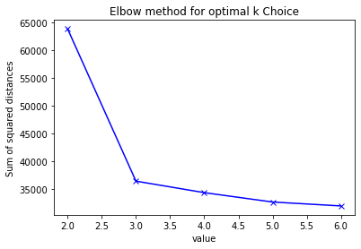

```python
# elbow method
SS_dist = []

values_for_k=range(2,7)
#print(values_for_k)

for k_val in values_for_k:
    k_means = KMeans(n_clusters=k_val)
    model = k_means.fit(DF_BOW)
    SS_dist.append(k_means.inertia_)

plt.plot(values_for_k, SS_dist, 'bx-')
plt.xlabel('value')
plt.ylabel('Sum of squared distances')
plt.title('Elbow method for optimal k Choice')
plt.show()
```

# Hiearchical clustering

The hierarchical clustering suggest that it is much clear that three centers is the optimal choice.

```python
def plot_dendrogram(model, **kwargs):
    # Create linkage matrix and then plot the dendrogram

    # create the counts of samples under each node
    counts = np.zeros(model.children_.shape[0])
    n_samples = len(model.labels_)
    for i, merge in enumerate(model.children_):
        current_count = 0
        for child_idx in merge:
            if child_idx < n_samples:
                current_count += 1  # leaf node
            else:
                current_count += counts[child_idx - n_samples]
        counts[i] = current_count

    linkage_matrix = np.column_stack([model.children_, model.distances_,
                                      counts]).astype(float)

    # Plot the corresponding dendrogram
    dendrogram(linkage_matrix, **kwargs)
```

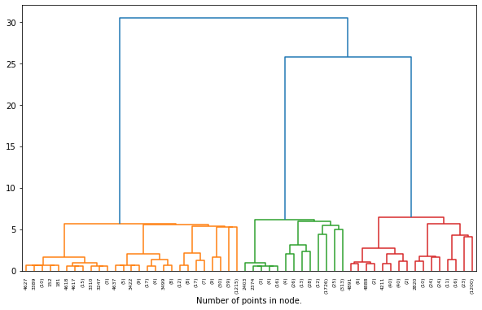

```python
model = AgglomerativeClustering(distance_threshold=0, n_clusters=None)
model.fit(DF_tfidf)
ax = plt.figure(figsize=(10,6))
plot_dendrogram(model, truncate_mode='level', p=5)
plt.xlabel("Number of points in node.")
plt.show()
ax.savefig('hierachical clustering.png')
```

# DBSCAN

```python
from sklearn.cluster import DBSCAN
from sklearn.datasets import make_blobs
from sklearn import metrics
```

```python
# Using PCA to reduce the dimensions
data = DF_BOW
pca_count = PCA(n_components=2,random_state = 1004)
reduce_data = pca_count.fit_transform(data)

pca_count = PCA(n_components=2,random_state = 1004)
reduce_data = pca_count.fit_transform(data)
```

```python
# data processing
X = StandardScaler().fit_transform(reduce_data)

le = preprocessing.LabelEncoder()
labels_true =  le.fit_transform(label)
```

```python
# #############################################################################
# Compute DBSCAN
db = DBSCAN(eps=0.3, min_samples=10).fit(X)
core_samples_mask = np.zeros_like(db.labels_, dtype=bool)
core_samples_mask[db.core_sample_indices_] = True
labels = db.labels_
```

```python
# Number of clusters in labels, ignoring noise if present.
n_clusters_ = len(set(labels)) - (1 if -1 in labels else 0)
n_noise_ = list(labels).count(-1)
```

```python
print('Estimated number of clusters: %d' % n_clusters_)
print('Estimated number of noise points: %d' % n_noise_)
print("Homogeneity: %0.3f" % metrics.homogeneity_score(labels_true, labels))
print("Completeness: %0.3f" % metrics.completeness_score(labels_true, labels))
print("V-measure: %0.3f" % metrics.v_measure_score(labels_true, labels))
print("Adjusted Rand Index: %0.3f"
      % metrics.adjusted_rand_score(labels_true, labels))
print("Adjusted Mutual Information: %0.3f"
      % metrics.adjusted_mutual_info_score(labels_true, labels))
print("Silhouette Coefficient: %0.3f"
      % metrics.silhouette_score(X, labels))
```

```
Estimated number of clusters: 4
Estimated number of noise points: 2
Homogeneity: 0.847
Completeness: 0.882
V-measure: 0.864
Adjusted Rand Index: 0.849
Adjusted Mutual Information: 0.864
Silhouette Coefficient: 0.962
```

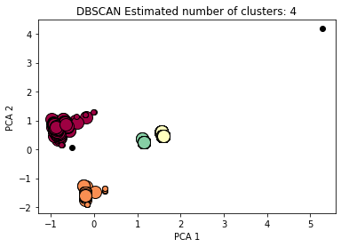

```python
# #############################################################################
# Plot result
import matplotlib.pyplot as plt

# Black removed and is used for noise instead.
unique_labels = set(labels)
colors = [plt.cm.Spectral(each)
          for each in np.linspace(0, 1, len(unique_labels))]
for k, col in zip(unique_labels, colors):
    if k == -1:
        # Black used for noise.
        col = [0, 0, 0, 1]

    class_member_mask = (labels == k)

    xy = X[class_member_mask & core_samples_mask]
    plt.plot(xy[:, 0], xy[:, 1], 'o', markerfacecolor=tuple(col),
             markeredgecolor='k', markersize=14)

    xy = X[class_member_mask & ~core_samples_mask]
    plt.plot(xy[:, 0], xy[:, 1], 'o', markerfacecolor=tuple(col),
             markeredgecolor='k', markersize=6)

plt.title('DBSCAN Estimated number of clusters: %d' % n_clusters_)
plt.xlabel('PCA 1')
plt.ylabel('PCA 2')
plt.show()
```

It seems that the DBSCAN has a different conclusion compared with other clustering method.

For example, under the DBSCAN, there are two clustering centers in the middle (green and yellow), However, this boundary is much more ambiguous.

# Summary

By using different clustering methods on the Twitter dataset, it is much clear that different topic tweets have different textual content.

For example, NFT and the Capflow have a distinct boundary between each dataset, while the BTC topic and ETH topic has a closer boundary, which is also the reason why DBSCAN has one more clustering part than k-means and Hierarchical clustering.

There are a lot of directions that can be explored deeply.

1. Is there any relationship between ETH and BTC quotes and Twitter text?
2. What can be predicted by analyzing the tweets related to the NFT?